# Course_Project_1

## Unzipping, loading and reading data

```r
library(data.table)
unzip("activity.zip")
activity <- fread("activity.csv")
head(activity)
```

```
##    steps       date interval
## 1:    NA 2012-10-01        0
## 2:    NA 2012-10-01        5
## 3:    NA 2012-10-01       10
## 4:    NA 2012-10-01       15
## 5:    NA 2012-10-01       20
## 6:    NA 2012-10-01       25
```

## Number of steps per day

1- Total number of steps taken per day

```r
steps <- aggregate(activity$steps, by = list(date  = activity$date), FUN = sum)
head(steps)
```

```
##         date     x
## 1 2012-10-01    NA
## 2 2012-10-02   126
## 3 2012-10-03 11352
## 4 2012-10-04 12116
## 5 2012-10-05 13294
## 6 2012-10-06 15420
```

2- Histogram of the total number of steps taken each day

```r
library(ggplot2)
```

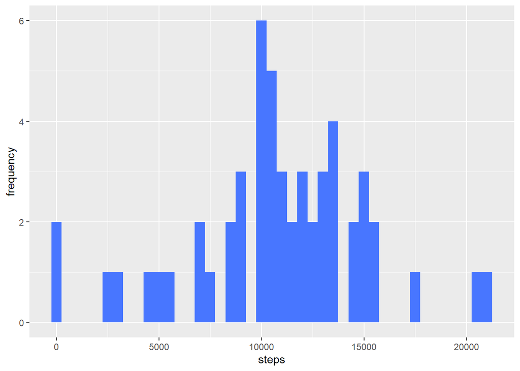

```r
ggplot(na.omit(steps), aes(x = x)) +
    geom_histogram(fill = "royalblue1", binwidth = 500) +
    labs(x = "steps", y = "frequency")
```

3- Mean and median of the total number of steps taken per day

```r
data_mm <- data.table("mean" = mean(steps$x, na.rm = TRUE), "median" = median(steps$x,  na.rm = TRUE))
data_mm
```

```
##        mean median
## 1: 10766.19  10765
```

## Average daily activity pattern

1- Time series plot of the 5-minute interval (x-axis) and the average number of steps taken, averaged across all days (y-axis)

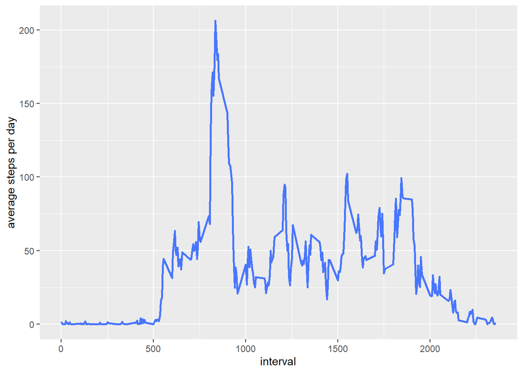

```r
series <- aggregate(activity$steps, by = list(date  = activity$date, interval = activity$interval), FUN=  mean)
data_int <- as.data.frame.table( tapply(series$x, series$interval, mean, na.rm = TRUE))
colnames(data_int) = c("interval", "steps")
data_int$interval <- as.numeric(as.character(data_int$interval))

ggplot(data_int, aes(x = interval , y = steps, group = 1)) +
  geom_line(color = "royalblue1", size = 1) +
  labs(x = "interval", y = "average steps per day")
```

2- 5-minute interval, on average across all the days in the dataset, with the maximum number of steps

```r
data_int <- as.data.table(data_int)
data_int[steps == max(data_int$steps), 1]
```

```
##    interval
## 1:      835
```

## Imputing missing values

1- Total number of missing values in the datase

```r
activity[is.na(steps), .N]
```

```
## [1] 2304
```

```r
activity[is.na(steps), "steps"] <- activity[, c(lapply(.SD, mean, na.rm = TRUE)), .SDcols = c("steps")]
```

```r
activity <- fread("activity.csv")
```

4- Histogram of the total number of steps taken each day and the mean and median of the total number of steps taken per day

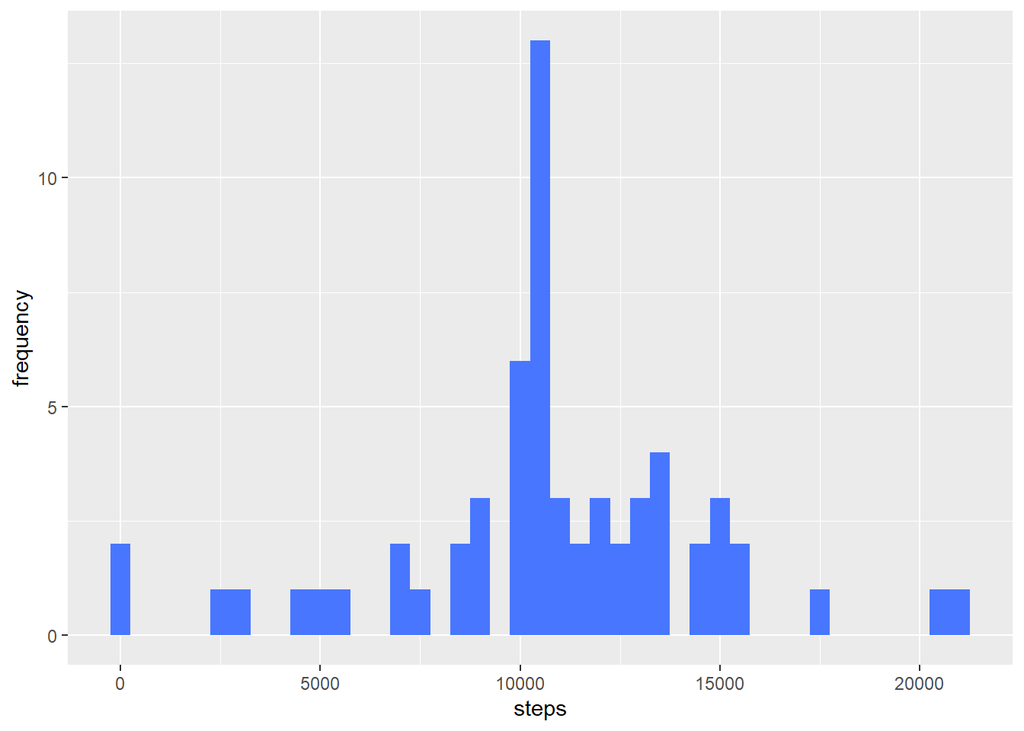

```r
activity2 <- fread("activity_filled.csv")
steps2 <- aggregate(activity2$steps, by = list(date  = activity2$date), FUN = sum)

ggplot(steps2, aes(x = x)) +
  geom_histogram(fill = "royalblue1", binwidth = 500) +
  labs(x = "steps", y = "frequency")
```

Mean and median

```r
data_mm2 <- data.table("mean" = mean(steps2$x, na.rm = TRUE), "median" = median(steps2$x,  na.rm = TRUE))
data_mm2
```

```
##        mean median
## 1: 10751.74  10656
```

The imputing of missing data slightly ltered the original mean and median

## Differences in activity patterns between weekdays and weekends

1- Creating a new factor variable in the dataset with two levels – “weekday” and “weekend”

```r
activity2[, date := as.POSIXct(date, format = "%Y-%m-%d")]
activity2[, "day"] <- weekdays(activity2$date)
week <- activity2$day
week <- ifelse(week == c("sabado", "domingo"), "weekend", "weekday")
activity2[, "weekend"] <- week
head(activity2)
```

```
##    steps       date interval   day weekend
## 1:    37 2012-10-01        0 lunes weekday
## 2:    37 2012-10-01        5 lunes weekday
## 3:    37 2012-10-01       10 lunes weekday
## 4:    37 2012-10-01       15 lunes weekday
## 5:    37 2012-10-01       20 lunes weekday
## 6:    37 2012-10-01       25 lunes weekday
```

2- Plot containing a time series plot of the 5-minute interval (x-axis) and the average number of steps taken, averaged across all weekday days or weekend days

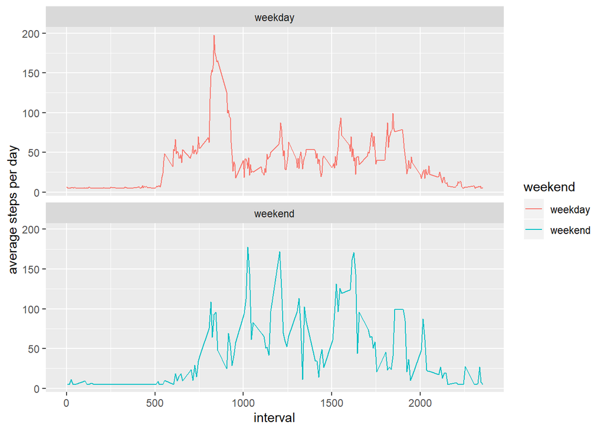

```r
series2 <- aggregate(activity2$steps, by = list(interval  = activity2$interval, weekend = activity2$weekend), FUN =  mean)

ggplot(series2 , aes(x = interval , y = x, color = weekend)) +
  geom_line() +
  labs(x = "interval", y = "average steps per day") +
  facet_wrap(~weekend , ncol = 1, nrow = 2)
```